# Predict Bike Sharing Demand with AutoGluon Template

## Step 4: Exploratory Data Analysis and Creating an additional feature

- Any additional feature will do, but a great suggestion would be to separate out the datetime into hour, day, or month parts.

```
array([[<AxesSubplot:title={'center':'season'}>,
        <AxesSubplot:title={'center':'holiday'}>,
        <AxesSubplot:title={'center':'workingday'}>],
       [<AxesSubplot:title={'center':'weather'}>,
        <AxesSubplot:title={'center':'temp'}>,
        <AxesSubplot:title={'center':'atemp'}>],
       [<AxesSubplot:title={'center':'humidity'}>,
        <AxesSubplot:title={'center':'windspeed'}>,
        <AxesSubplot:title={'center':'casual'}>],
       [<AxesSubplot:title={'center':'registered'}>,
        <AxesSubplot:title={'center':'count'}>, <AxesSubplot:>]],
      dtype=object)
```

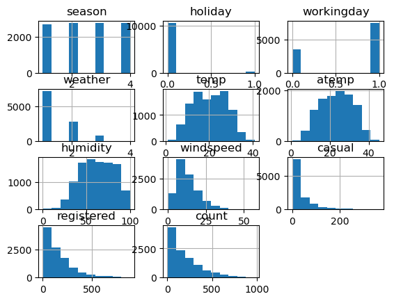

```python
# Create a histogram of all features to show the distribution of each one relative to the data. This is part of the exploritory data analysis
train.hist()
```

```python
# create a new feature
# convert datetime to datetime object
train['datetime'] = pd.to_datetime(train['datetime'])
test['datetime'] = pd.to_datetime(test['datetime'])


train["hour"] = train['datetime'].dt.hour
train["day"] = train['datetime'].dt.day
train["month"] = train['datetime'].dt.month
test["hour"] = test['datetime'].dt.hour
test["day"] = test['datetime'].dt.day
test["month"] = test['datetime'].dt.month
```

## Make category types for these so models know they are not just numbers

- AutoGluon originally sees these as ints, but in reality they are int representations of a category.
- Setting the dtype to category will classify these as categories in AutoGluon.

```python
train["season"] = train['season'].astype('category')
train["weather"] = train['weather'].astype('category')
test["season"] = test['season'].astype('category')
test["weather"] = test['weather'].astype('category')
```

```python
# View are new feature
train.head()
```

|  | datetime | season | holiday | workingday | weather | temp | atemp | humidity | windspeed | casual | registered | count | hour | day | month |
| --- | --- | --- | --- | --- | --- | --- | --- | --- | --- | --- | --- | --- | --- | --- | --- |
| 0 | 2011-01-01 00:00:00 | 1 | 0 | 0 | 1 | 9.84 | 14.395 | 81 | 0.0 | 3 | 13 | 16 | 0 | 1 | 1 |
| 1 | 2011-01-01 01:00:00 | 1 | 0 | 0 | 1 | 9.02 | 13.635 | 80 | 0.0 | 8 | 32 | 40 | 1 | 1 | 1 |
| 2 | 2011-01-01 02:00:00 | 1 | 0 | 0 | 1 | 9.02 | 13.635 | 80 | 0.0 | 5 | 27 | 32 | 2 | 1 | 1 |
| 3 | 2011-01-01 03:00:00 | 1 | 0 | 0 | 1 | 9.84 | 14.395 | 75 | 0.0 | 3 | 10 | 13 | 3 | 1 | 1 |
| 4 | 2011-01-01 04:00:00 | 1 | 0 | 0 | 1 | 9.84 | 14.395 | 75 | 0.0 | 0 | 1 | 1 | 4 | 1 | 1 |

```
array([[<AxesSubplot:title={'center':'datetime'}>,
        <AxesSubplot:title={'center':'holiday'}>,
        <AxesSubplot:title={'center':'workingday'}>,
        <AxesSubplot:title={'center':'temp'}>],
       [<AxesSubplot:title={'center':'atemp'}>,
        <AxesSubplot:title={'center':'humidity'}>,
        <AxesSubplot:title={'center':'windspeed'}>,
        <AxesSubplot:title={'center':'casual'}>],
       [<AxesSubplot:title={'center':'registered'}>,
        <AxesSubplot:title={'center':'count'}>,
        <AxesSubplot:title={'center':'hour'}>,
        <AxesSubplot:title={'center':'day'}>],
       [<AxesSubplot:title={'center':'month'}>, <AxesSubplot:>,
        <AxesSubplot:>, <AxesSubplot:>]], dtype=object)
```

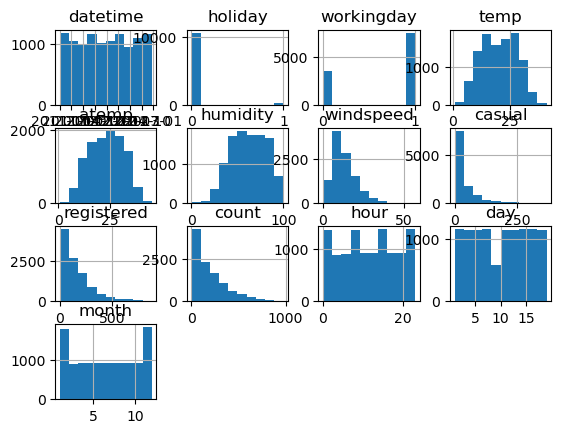

```python
# View histogram of all features again now with the hour feature

train.hist()
```

## Step 5: Rerun the model with the same settings as before, just with more features

```python
train_mf = train.drop(["casual", "registered"], axis=1)

predictor_new_features = TabularPredictor(label="count", eval_metric="rmse", problem_type="regression").fit(
    train_data=train_mf, time_limit=600, presets="best_quality"
)
```

[output not shown]

[output cut: 472 more lines]

```
	-32.2315	 = Validation score   (-root_mean_squared_error)
	35.8s	 = Training   runtime
	0.61s	 = Validation runtime
Fitting model: CatBoost_BAG_L2 ... Training model for up to 62.24s of the 62.2s of remaining time.
	Fitting 8 child models (S1F1 - S1F8) | Fitting with ParallelLocalFoldFittingStrategy (2 workers, per: cpus=1, gpus=0, memory=0.92%)
	-30.6868	 = Validation score   (-root_mean_squared_error)
	61.02s	 = Training   runtime
	0.07s	 = Validation runtime
Fitting model: WeightedEnsemble_L3 ... Training model for up to 360.0s of the -5.11s of remaining time.
	Ensemble Weights: {'CatBoost_BAG_L2': 0.835, 'RandomForestMSE_BAG_L2': 0.132, 'CatBoost_BAG_L1': 0.022, 'KNeighborsDist_BAG_L1': 0.011}
	-30.6262	 = Validation score   (-root_mean_squared_error)
	0.41s	 = Training   runtime
	0.0s	 = Validation runtime
AutoGluon training complete, total runtime = 438.76s ... Best model: "WeightedEnsemble_L3"
TabularPredictor saved. To load, use: predictor = TabularPredictor.load("AutogluonModels/ag-20240417_094907")
```

```python
predictor_new_features.fit_summary()
```

```
*** Summary of fit() ***
Estimated performance of each model:
                    model   score_val              eval_metric  pred_time_val    fit_time  pred_time_val_marginal  fit_time_marginal  stack_level  can_infer  fit_order
0     WeightedEnsemble_L3  -30.626195  root_mean_squared_error       3.045121  391.431869                0.000646           0.410441            3       True         10
1         CatBoost_BAG_L2  -30.686831  root_mean_squared_error       2.436024  355.223947                0.065784          61.019737            2       True          9
2  RandomForestMSE_BAG_L2  -32.231473  root_mean_squared_error       2.978691  330.001691                0.608451          35.797481            2       True          8
3     WeightedEnsemble_L2  -33.187237  root_mean_squared_error       1.106469  235.361950                0.000552           0.394241            2       True          7
4         CatBoost_BAG_L1  -33.902848  root_mean_squared_error       0.467254  217.760838                0.467254         217.760838            1       True          4
5  RandomForestMSE_BAG_L1  -38.408907  root_mean_squared_error       0.579998   17.152204                0.579998          17.152204            1       True          3
6    ExtraTreesMSE_BAG_L1  -38.509984  root_mean_squared_error       0.696386    8.451524                0.696386           8.451524            1       True          5
7   KNeighborsDist_BAG_L1  -84.125061  root_mean_squared_error       0.058665    0.054666                0.058665           0.054666            1       True          2
8   KNeighborsUnif_BAG_L1 -101.546199  root_mean_squared_error       0.082387    0.044298                0.082387           0.044298            1       True          1
9  NeuralNetFastAI_BAG_L1 -103.085030  root_mean_squared_error       0.485550   50.740680                0.485550          50.740680            1       True          6
Number of models trained: 10
Types of models trained:
{'StackerEnsembleModel_RF', 'StackerEnsembleModel_XT', 'WeightedEnsembleModel', 'StackerEnsembleModel_KNN', 'StackerEnsembleModel_CatBoost', 'StackerEnsembleModel_NNFastAiTabular'}
Bagging used: True  (with 8 folds)
Multi-layer stack-ensembling used: True  (with 3 levels)
Feature Metadata (Processed):
(raw dtype, special dtypes):
('category', [])             : 2 | ['season', 'weather']
('float', [])                : 3 | ['temp', 'atemp', 'windspeed']
('int', [])                  : 4 | ['humidity', 'hour', 'day', 'month']
('int', ['bool'])            : 2 | ['holiday', 'workingday']
('int', ['datetime_as_int']) : 3 | ['datetime', 'datetime.year', 'datetime.dayofweek']
*** End of fit() summary ***
```

[output not shown]

[output cut: 78 more lines]

```
 7    0.054666                0.058665           0.054666            1
 8    0.044298                0.082387           0.044298            1
 9   50.740680                0.485550          50.740680            1

    can_infer  fit_order
 0       True         10
 1       True          9
 2       True          8
 3       True          7
 4       True          4
 5       True          3
 6       True          5
 7       True          2
 8       True          1
 9       True          6  }
```

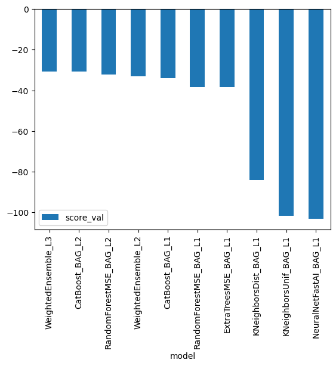

```python
# compare models
predictor_new_features.leaderboard(silent=True).plot(kind="bar", x = "model", y="score_val")
```

```python
# Remember to set all negative values to zero
predictions_new_features = predictor_new_features.predict(test)

predictions_new_features[predictions_new_features <0] = 0
predictions_new_features.describe()
```

```
count    6493.000000
mean      140.687469
std       118.354027
min         0.000000
25%        56.440453
50%       113.348106
75%       185.497192
max       789.797058
Name: count, dtype: float64
```

```python
# Same submitting predictions
submission_new_features = pd.read_csv("sampleSubmission.csv")
submission_new_features["count"] = predictions_new_features
submission_new_features.to_csv("submission_new_features.csv", index=False)
```

```python
!kaggle competitions submit -c bike-sharing-demand -f submission_new_features.csv -m "new features second run"
```

```
Successfully submitted to Bike Sharing Demand
```

```python
!kaggle competitions submissions -c bike-sharing-demand | tail -n +1 | head -n 10
```

```
fileName                     date                 description                        status    publicScore  privateScore
---------------------------  -------------------  ---------------------------------  --------  -----------  ------------
submission_new_features.csv  2024-04-17 10:04:03  new features second run            complete  0.77426      0.77426
submission_new_features.csv  2024-04-17 10:00:07  new features second run            error
submission_new_features.csv  2024-04-17 09:59:21  new features second run            error
submission.csv               2024-04-17 09:47:32  second raw submission              complete  1.79313      1.79313
submission_new_hpo.csv       2024-04-16 19:56:52  new features with hyperparameters  complete  0.49876      0.49876
submission_new_features.csv  2024-04-16 17:26:18  new features                       complete  0.74963      0.74963
submission.csv               2024-04-16 16:22:13  first raw submission               complete  1.79685      1.79685
```

## Step 6: Hyper parameter optimization

- There are many options for hyper parameter optimization.
- Options are to change the AutoGluon higher level parameters or the individual model hyperparameters.
- The hyperparameters of the models themselves that are in AutoGluon. Those need the `hyperparameter` and `hyperparameter_tune_kwargs` arguments.

```python
train_mf = train.drop(["casual", "registered"], axis=1)

# exclude KNN and NN model since they are not top performers
excluded_model_types = ['KNN', 'NN']

hyperparameter_tune_kwargs = {
    'num_trials': 3,
    'scheduler' : 'local',
    'searcher': 'auto',
}

# Fit TabularPredictor with hyperparameter optimization
predictor_new_hpo = TabularPredictor(label="count",
                                          eval_metric="root_mean_squared_error",
                                          problem_type="regression").fit(
                                          train_data=train_mf, time_limit=1200,
                                           excluded_model_types=excluded_model_types,
                                          hyperparameter_tune_kwargs=hyperparameter_tune_kwargs,
                                          presets="best_quality"
                                          )
```

[output not shown]

```python
predictor_new_hpo.fit_summary()
```

[output not shown]

[output not shown]

[output cut: 305 more lines]

```
 13            1       True         24
 14            1       True          9
 15            1       True         17
 16            1       True         15
 17            1       True         14
 18            1       True         21
 19            1       True          7
 20            1       True         25
 21            1       True          8
 22            1       True         16
 23            1       True         26
 24            1       True          3
 25            1       True         19
 26            1       True          4
 27            1       True         11  }
```

```python
# Remember to set all negative values to zero
prediction_hyp = predictor_new_hpo.predict(test)
prediction_hyp.describe()

prediction_hyp[prediction_hyp <0] = 0
```

```python
# Same submitting predictions
submission_new_hpo = pd.read_csv("sampleSubmission.csv")
submission_new_hpo["count"] = prediction_hyp
submission_new_hpo.to_csv("submission_new_hpo.csv", index=False)
```

```python
!kaggle competitions submit -c bike-sharing-demand -f submission_new_hpo.csv -m "new features with hyperparameters 2"
```

```
Successfully submitted to Bike Sharing Demand
```

```python
!kaggle competitions submissions -c bike-sharing-demand | tail -n +1 | head -n 10
```

```
fileName                     date                 description                          status    publicScore  privateScore
---------------------------  -------------------  -----------------------------------  --------  -----------  ------------
submission_new_hpo.csv       2024-04-17 12:26:39  new features with hyperparameters 2  complete  1.41215      1.41215
submission_new_features.csv  2024-04-17 10:04:03  new features second run              complete  0.77426      0.77426
submission_new_features.csv  2024-04-17 10:00:07  new features second run              error
submission_new_features.csv  2024-04-17 09:59:21  new features second run              error
submission.csv               2024-04-17 09:47:32  second raw submission                complete  1.79313      1.79313
submission_new_hpo.csv       2024-04-16 19:56:52  new features with hyperparameters    complete  0.49876      0.49876
submission_new_features.csv  2024-04-16 17:26:18  new features                         complete  0.74963      0.74963
submission.csv               2024-04-16 16:22:13  first raw submission                 complete  1.79685      1.79685
```

Yes, got a new score